# Bootstrap para datos funcionales

# Bootstrap para datos simulados

Primero, veamos una muestra de tama?o 100 los modelos (1) y (2):

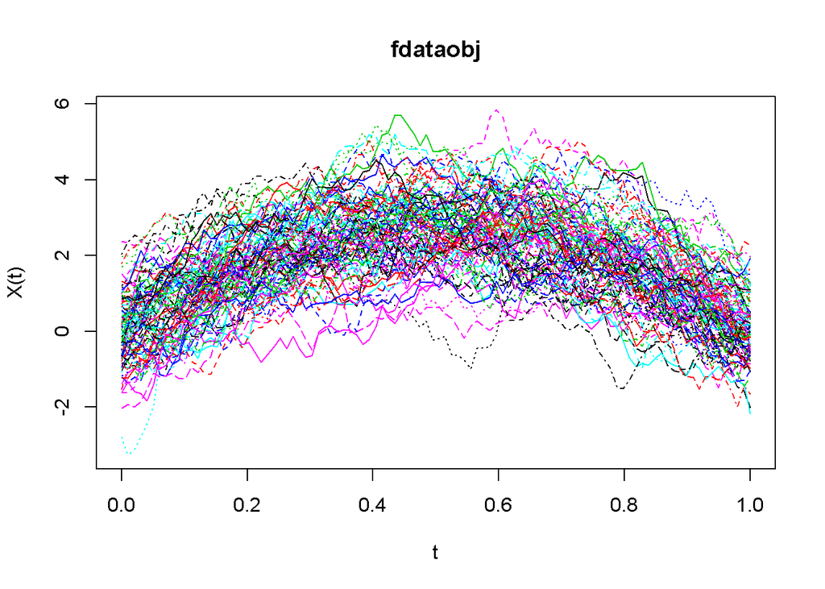

```r
kNs <- 100
#100 equidistant points (ts = timesteps).
kNc <- 100
# Number of curves.
ts <- linspace(0, 1, n = kNs)
# Initialize covariance matrix for first e(t) with zeroes.
cov.e <- matrix(rep(0, len=kNs*kNs), nrow=kNs, ncol=kNs)
# Initializ covariance matrix for h(t) with zeroes.
cov.h <- matrix(rep(0, len=kNs*kNs), nrow=kNs, ncol=kNs)
E1 <- numeric(kNs)
# Fill up covariances and expected values as described in the paper.
for (i in 1:kNs) {
  E1[i] <- 10*ts[i]*(1-ts[i])
  for (j in 1:kNs) {
    cov.e[i,j] <- exp(-(abs(ts[i] - ts[j]))/0.3)
    cov.h[i,j] <- min(ts[i], ts[j])
  }
}
mu <- numeric(kNs)
e.S0 <- mvrnorm(n = kNc, mu=mu, Sigma=cov.e)
# Sample 1 to 5 error, first three with error e(t), last two with error h(t).
e.S1 <- mvrnorm(n = kNc, mu=mu, Sigma=cov.h)
S0 <- sweep(e.S0, 2, E1, "+")
S1 <- sweep(e.S1, 2, E1, "+")
A <- fdata(S0, ts)
B <- fdata(S1, ts)
plot(A)
```

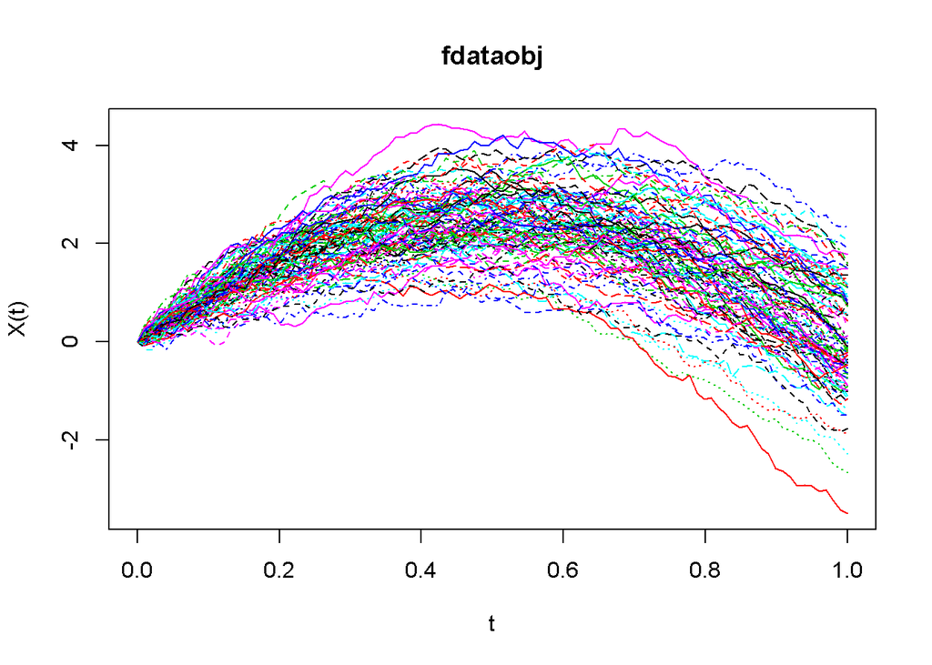

```r
plot(B)
```

Ahora, estimemos algunas funciones basadas en la muestra para el modelo A:

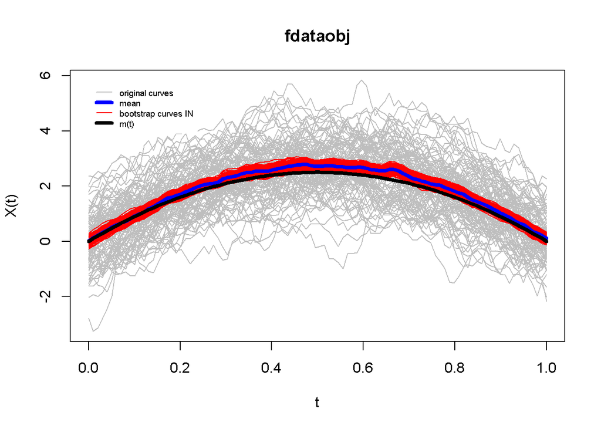

```r
control <- list("col"=c("grey","blue","red"),"lty"=c(1,1,1),"lwd"=c(1,4,1))
bsA.mean <- fdata.bootstrap2(A, E, ts, statistic=func.mean, smo=0.05, nb=500, draw=TRUE, draw.control=control)
```

y para el modelo B:

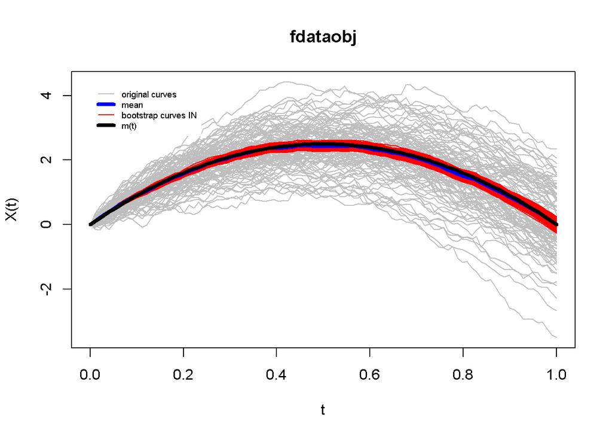

```r
bsB.mean <- fdata.bootstrap2(B, E, ts, statistic=func.mean, smo=0.05, nb=500, draw=TRUE, draw.control=control)
```

Estimando medianas (usando la mediana de Fraiman-Muniz), usando el método de bootstrap clásico (sin usar smoothing), obtenemos, para el modelo A:

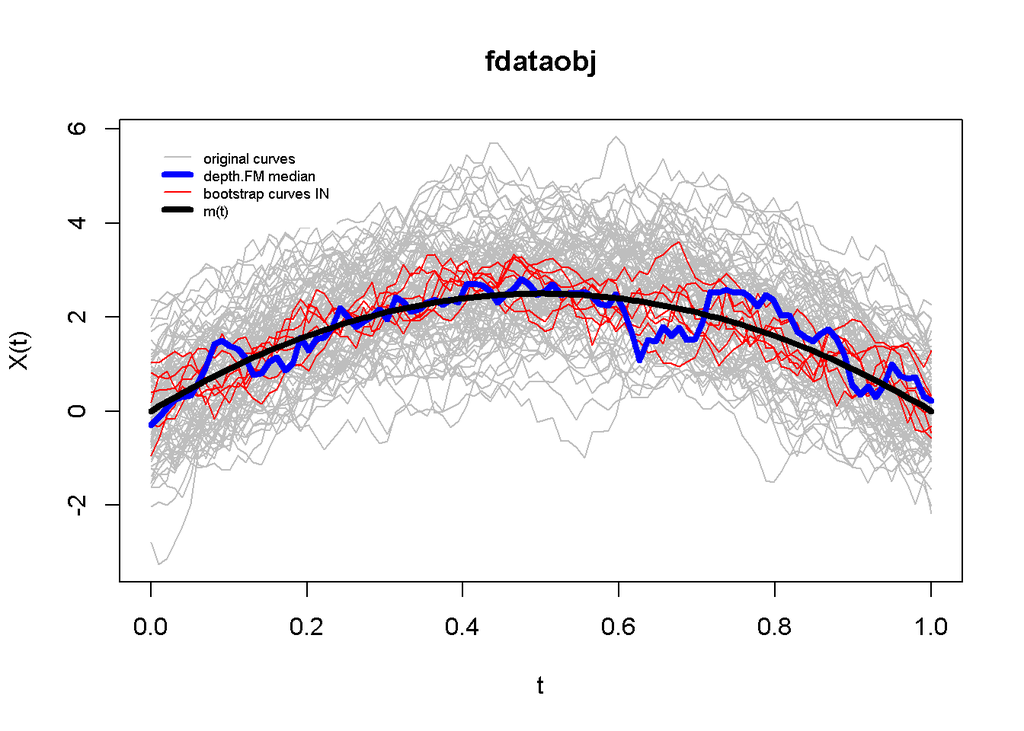

```r
bsA2.FMmed <- fdata.bootstrap2(A, E, ts, statistic=func.med.FM, smo=0, nb=500, draw=TRUE, draw.control=control)
```

y para el modelo B:

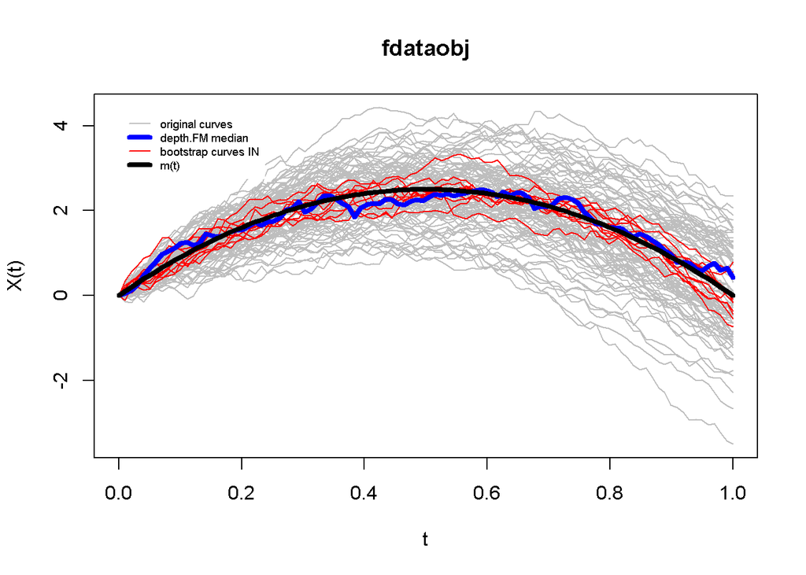

```r
bsB2.FMmed <- fdata.bootstrap2(B, E, ts, statistic=func.med.FM, smo=0, nb=500, draw=TRUE, draw.control=control)
```

Como se mencionó, este método no es muy bueno cuando el estadístico es un mismo elemento de la muestra. Ahora, consideremos un beta=0.05 y empleemos el bootstrap suavizado para calcular medianas. Primero para el modelo A:

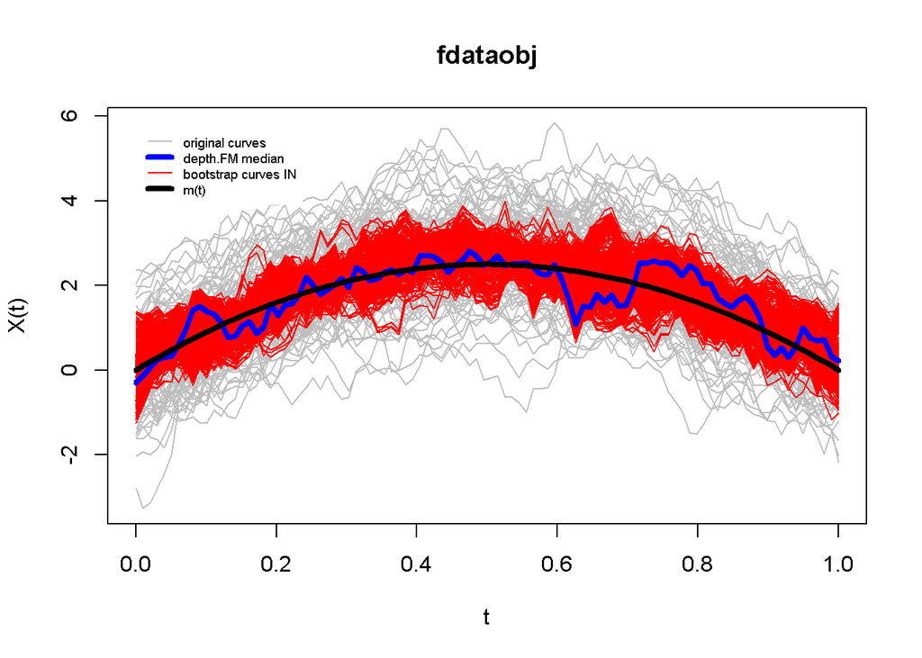

```r
bsA3.FMmed <- fdata.bootstrap2(A, E, ts, statistic=func.med.FM, smo=0.05, nb=500, draw=TRUE, draw.control=control)
```

Ahora, para el modelo B:

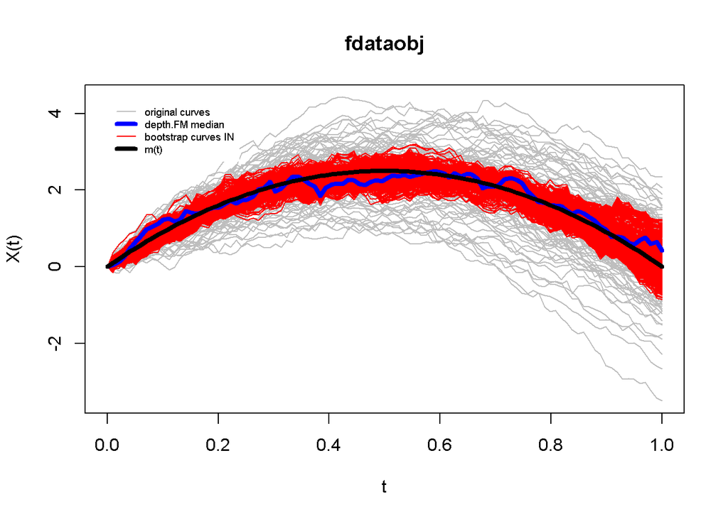

```r
bsB3.FMmed <- fdata.bootstrap2(B, E, ts, statistic=func.med.FM, smo=0.05, nb=500, draw=TRUE, draw.control=control)
```

Veamos que ocurre si escogemos un beta más pequeño, tipo un beta=0.01. En el modelo A:

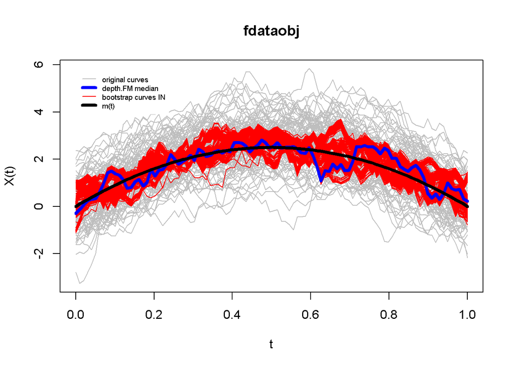

```r
bsA4.FMmed <- fdata.bootstrap2(A, E, ts, statistic=func.med.FM, smo=0.01, nb=500, draw=TRUE, draw.control=control)
```

Y para el modelo B:

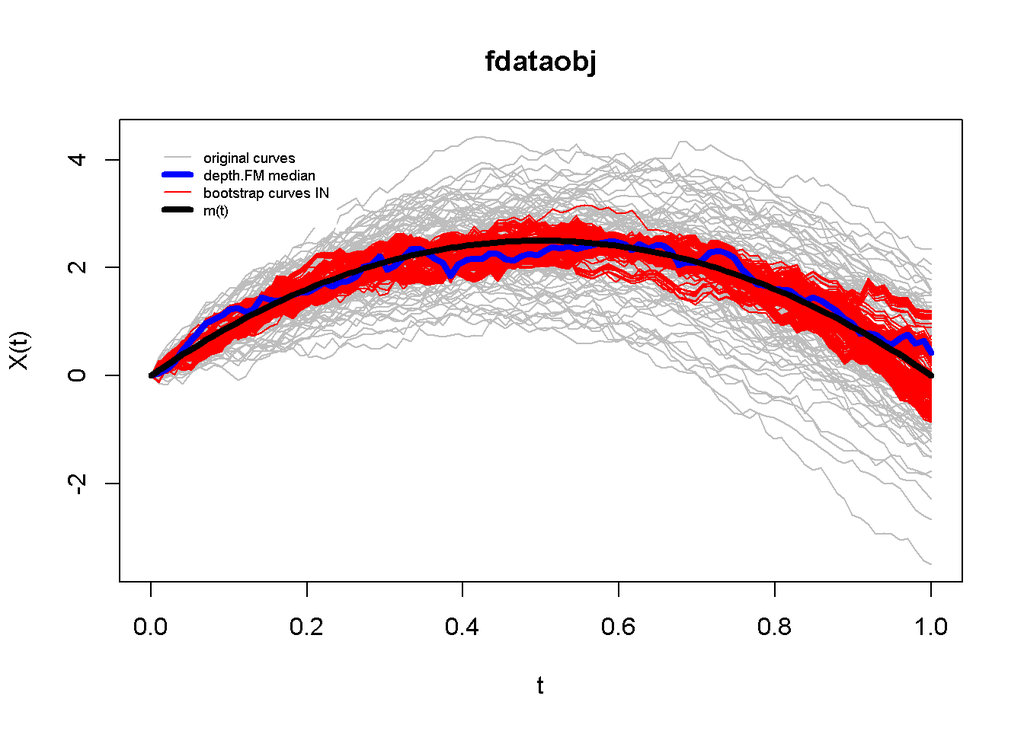

```r
bsB4.FMmed <- fdata.bootstrap2(B, E, ts, statistic=func.med.FM, smo=0.01, nb=500, draw=TRUE, draw.control=control)
```

Y si probamos con un beta mÃ¡s grande, digamos, con beta=0.1, tenemos, en el modelo A:

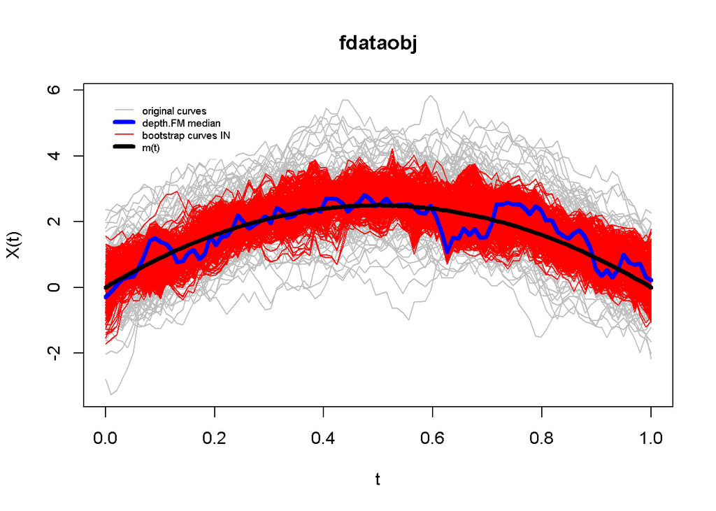

```r
bsA5.FMmed <- fdata.bootstrap2(A, E, ts, statistic=func.med.FM, smo=0.1, nb=500, draw=TRUE, draw.control=control)
```

Y para el modelo B:

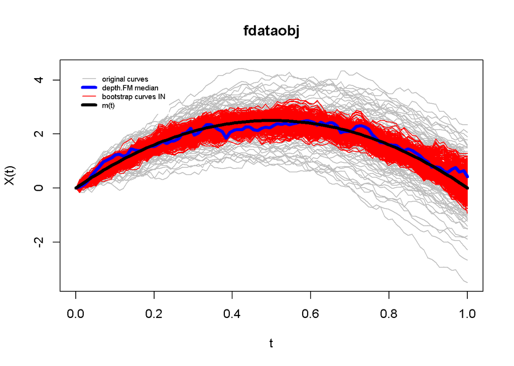

```r
bsB5.FMmed <- fdata.bootstrap2(B, E, ts, statistic=func.med.FM, smo=0.1, nb=500, draw=TRUE, draw.control=control)
```

Ahora, veamos como estima la varianza para ambos modelos el bootstrap. Para el modelo A:

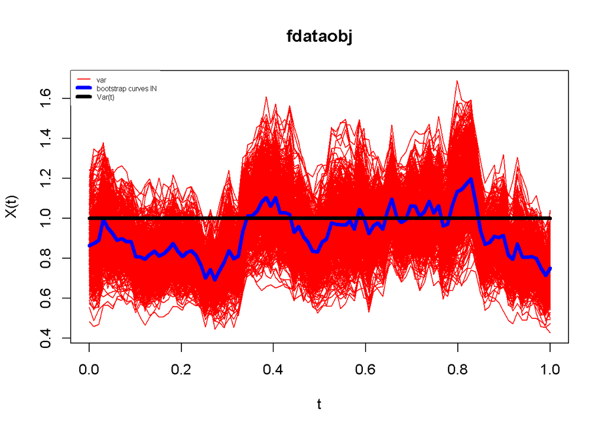

```r
varA <- numeric(100) + 1
bs.varA <- fdata.bootstrap3(A, varA, ts, statistic=func.var, nb=500, draw=TRUE, draw.control=control)
```

Y para el modelo B:

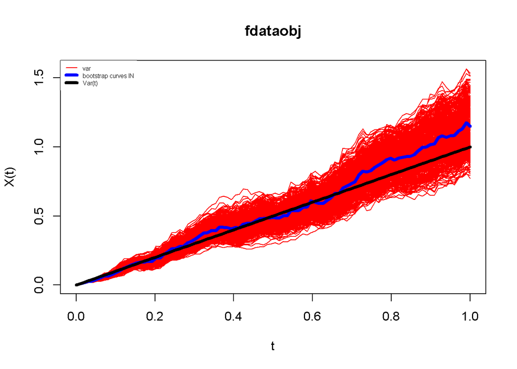

```r
bs.varB <- fdata.bootstrap3(B, ts, ts, statistic=func.var, nb=500, draw=TRUE, draw.control=control)
```

# Datos MCO

Ahora, consideremos la base de datos de MCO que esta en el paquete fda.usc

Veamos la primer muestra, que son las células de los ratones a los que no se le aplicó la droga.

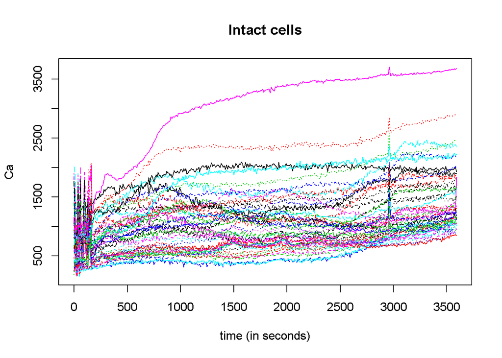

```r
data(MCO)
A <- MCO$intact[MCO$classintact==1]
B <- MCO$intact[MCO$classintact==2]
plot(A)
```

Ahora, la segunda muestra, que son las células de las ratas a los que si se le aplicó la droga.

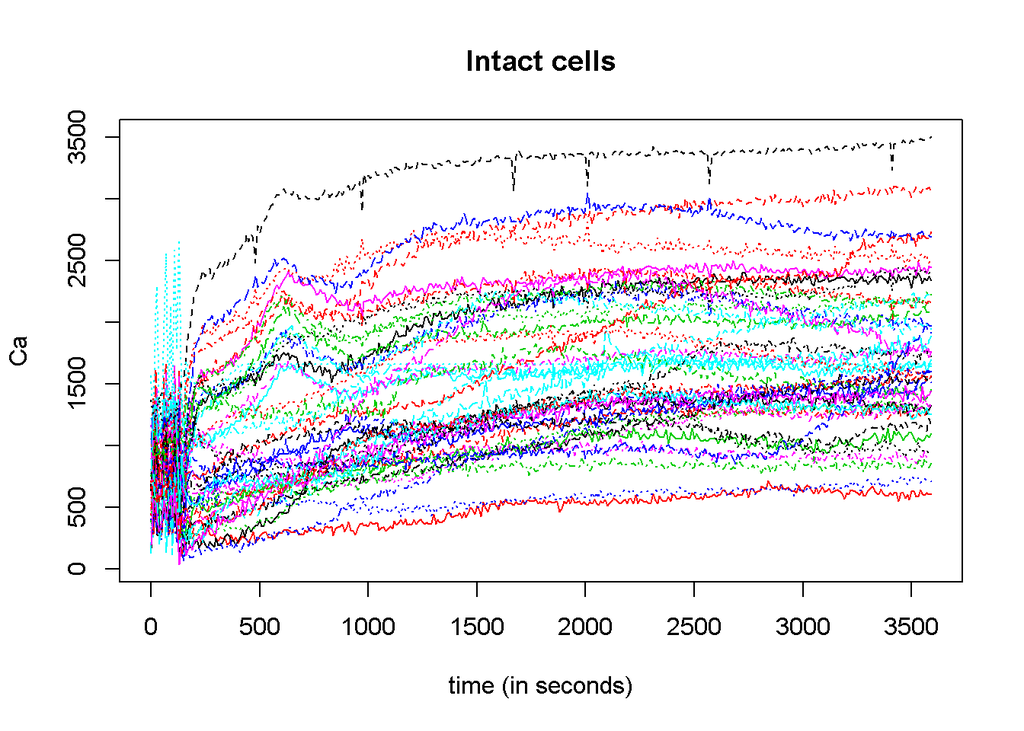

```r
plot(B)
```

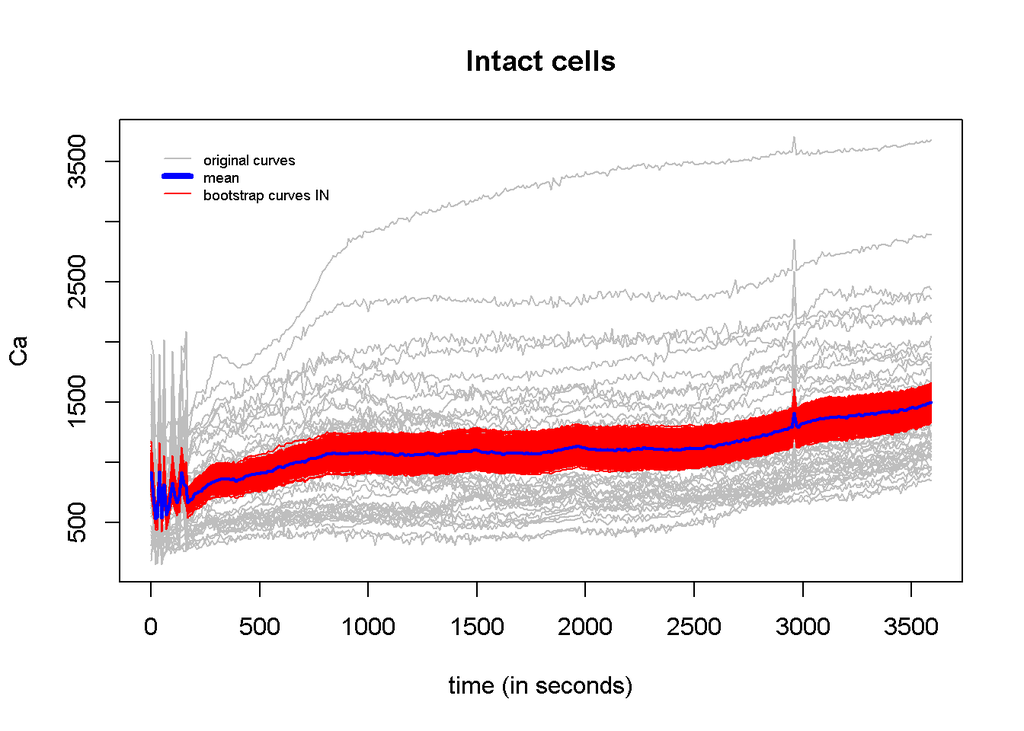

```r
control <- list("col"=c("grey","blue","red"),"lty"=c(1,1,1),"lwd"=c(1,2,1))
bs.meanA <- fdata.bootstrap4(A, statistic=func.mean, smo=0.05, nb=500, draw=TRUE, draw.control=control)
```

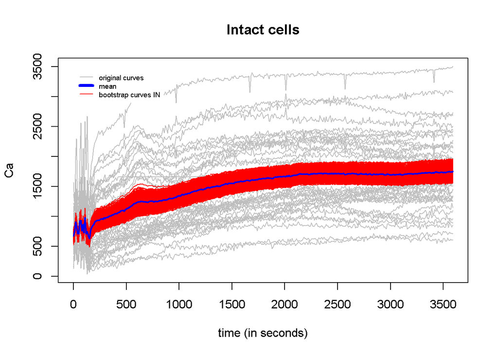

```r
control <- list("col"=c("grey","blue","red"),"lty"=c(1,1,1),"lwd"=c(1,2,1))
bs.meanB <- fdata.bootstrap4(B, statistic=func.mean, smo=0.05, nb=500, draw=TRUE, draw.control=control)
```

Ahora veamos como cruzan las bandas de confianza

[output not shown]

[output not shown]

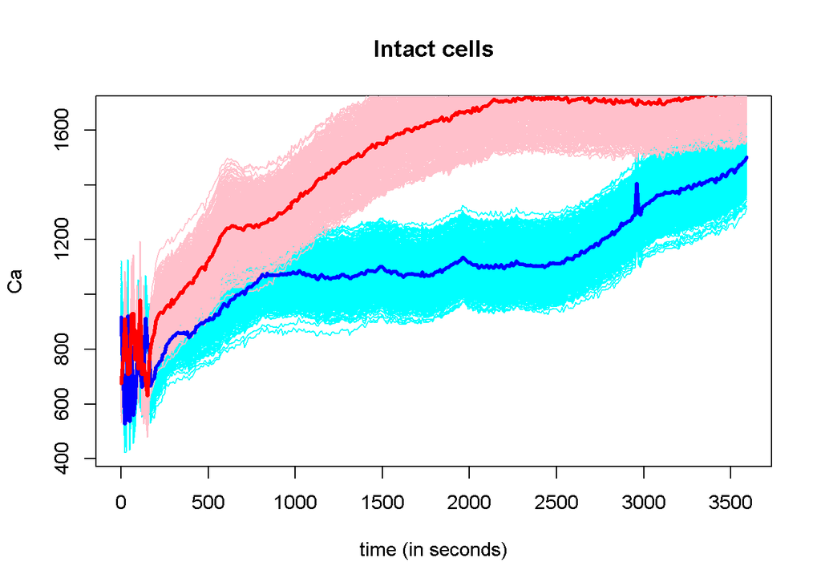

# Datos Colcap

```r
library(openxlsx)
```

```r
fdata.bootstrap2 <-function(fdataobj,statistic=func.mean,alpha=0.05,nb=200,
                            smo=0.0,draw=FALSE,draw.control=NULL,...){
  if (!is.fdata(fdataobj)) fdataobj=fdata(fdataobj)
  data<-fdataobj[["data"]]
  estmues<-statistic(fdataobj,...)
  nr<-nrow(fdataobj)
  nc<-ncol(fdataobj)
  tt =fdataobj[["argvals"]]
  rtt=fdataobj[["rangeval"]]
  names=fdataobj[["names"]]
  distboot<-matrix(NA,nrow=nb)
  estboot<-matrix(NA,nrow=nb,ncol=nc)
  pb=txtProgressBar(min=0,max=nb,style=3)
  for (i in 1:nb){
    setTxtProgressBar(pb,i-0.5)
    bmuestra<-fdataobj[sample(1:nr,size=nr,replace=TRUE),]
    if (smo>0) {
      bmuestra[["data"]]<-bmuestra[["data"]]+mvrnorm(n=nr,rep(0,nc),var(data)*smo)
    }
    stat<-statistic(bmuestra,...)
    estboot[i,]<-stat[["data"]]
    setTxtProgressBar(pb,i)
  }
  close(pb)
  center<-estmues
  #for (i in 1:nb){  aux<-fdata(estboot[i,],tt,rtt)
  #  distboot[i]<-metric.lp(center,aux,...)  }
  #print(dim(distboot))
  distboot<-metric.lp(fdata(estboot,tt,rtt),center,...)
  dist<-max(distboot[rank(distboot)<=floor((1-alpha)*nb)])
  resample<-fdata(estboot,tt,rtt,names)
  insample <- resample[distboot<=dist]
  if (draw){
    if (is.null(draw.control)) draw.control=list("col"=c("grey","blue","pink"),"lty"=c(2,1,1),"lwd"=c(1,2,1))
    if (is.null(draw.control$lwd)) draw.control$lwd=c(1,2,1)
    if (is.null(draw.control$lty)) draw.control$lty=c(2,1,1)
    if (is.null(draw.control$col)) draw.control$col=c("grey","blue","pink")
    #plot(fdataobj,lwd=draw.control$lwd[1],lty=draw.control$lty[1],col=draw.control$col[1])
    # for(i in 1:nb){
    #if (distboot[i]<=dist) lines(tt,estboot[i,],lwd=draw.control$lwd[3],lty=draw.control$lty[3],col=draw.control$col[3])
    #else lines(tt,estboot[i,],lwd=draw.control$lwd[4],lty=draw.control$lty[4],
    #col=draw.control$col[4])  }
    plot(resample[distboot<=dist],lwd=draw.control$lwd[3],lty=draw.control$lty[3],col=draw.control$col[3])
    lines(estmues,lwd=draw.control$lwd[2],lty=draw.control$lty[2],col=draw.control$col[2])
    legend('bottomleft',legend=c(stat$names$main,"bootstrap curves IN"),
           lty=draw.control$lty,lwd=draw.control$lwd,col=draw.control$col,cex=0.9,box.col=0)
  }
  return(list("statistic"=estmues,"dband"= dist,"rep.dist"=distboot,
              "resample"=resample,fdataobj=fdataobj, "samplesin"=insample))
}
data <- read.xlsx("acciones.xlsx", rowNames=TRUE) #ignorar fecha
dims <- dim(data)
n <- dims[1]
m <- dims[2]
aux <- m-1

returns <- matrix(rep(0, len=(n-1)*m), nrow=(n-1), ncol=m)

for (i in 2:n-1){
  for (j in 1:m){
     #print(i)
     #print(j)
     returns[i-1, j] <- (data[i, j] - data[i-1, j])/data[i-1, j]
  }
}

fsample2 <- fdata(t(returns))
```

Veamos como son los datos:

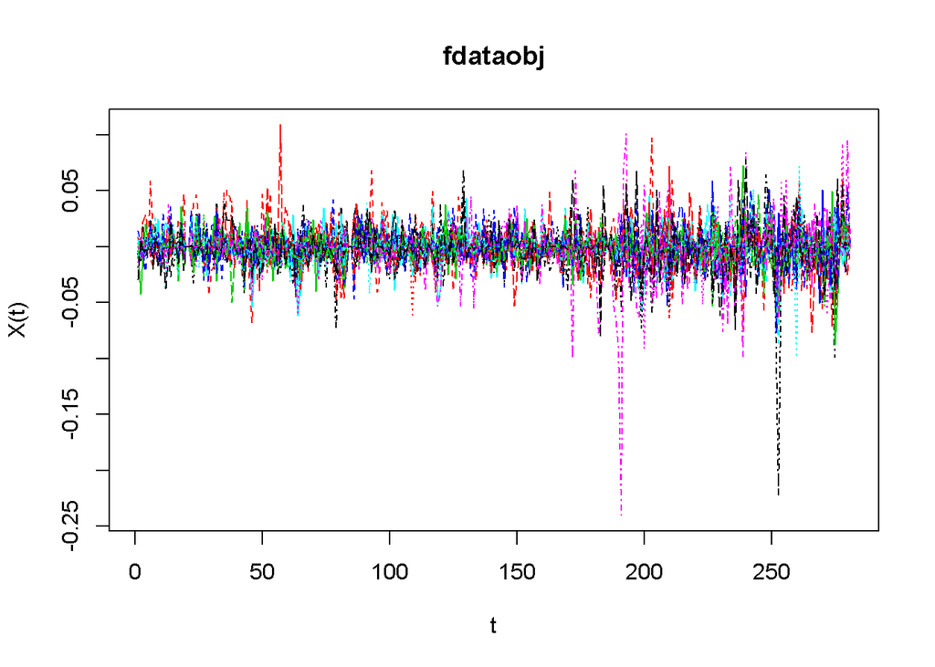

```r
plot(fsample2)
```

Ahora veamos las media bootstrap con su banda de confianza:

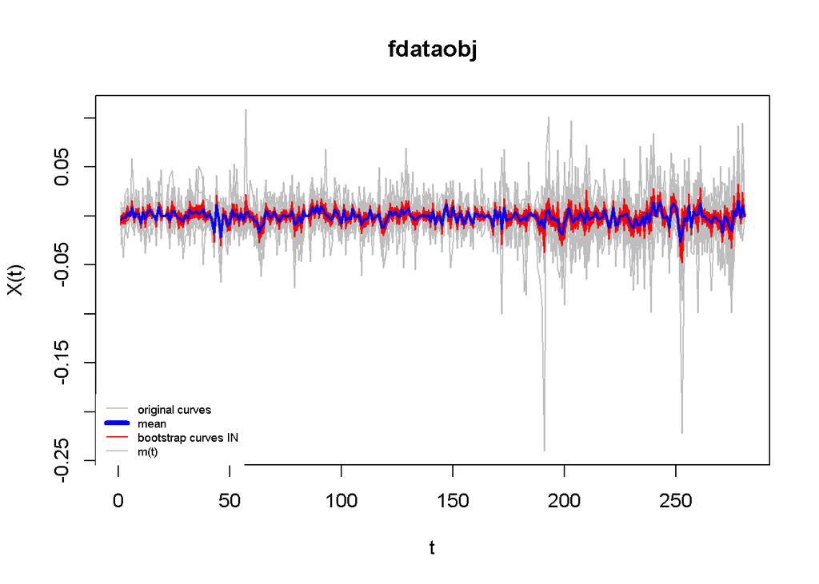

```r
bs.mean <- fdata.bootstrap6(fsample2, statistic=func.mean, nb=500, draw=TRUE, draw.control=control)
```

Y ahora, la varianza:

[figure not shown]

```r
bs.var <- fdata.bootstrap2(fsample2, statistic=func.var, nb=500, draw=TRUE, draw.control=control)
```

Veamos las bandas de confianza para los diferentes sectores:

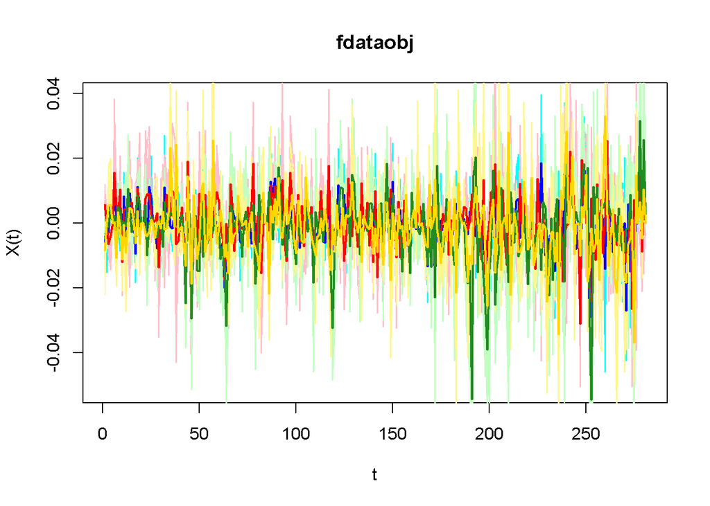

```r
bs.mean.fin <- fdata.bootstrap2(fin, statistic=func.mean, nb=500, draw=FALSE, draw.control=control)
bs.mean.min <- fdata.bootstrap2(min, statistic=func.mean, nb=500, draw=FALSE, draw.control=control)
bs.mean.con <- fdata.bootstrap2(con, statistic=func.mean, nb=500, draw=FALSE, draw.control=control)
bs.mean.otr <- fdata.bootstrap2(otr, statistic=func.mean, nb=500, draw=FALSE, draw.control=control)
inFin <- bs.mean.fin$samplesin
inMin <- bs.mean.min$samplesin
inCon <- bs.mean.con$samplesin
inOtr <- bs.mean.otr$samplesin

mean.fin <- bs.mean.fin$statistic
mean.min <- bs.mean.min$statistic
mean.con <- bs.mean.con$statistic
mean.otr <- bs.mean.otr$statistic

plot(inFin, lwd=1,lty=1,col='cyan')
lines(inMin, lwd=1,lty=1,col='pink')
lines(inCon, lwd=1, lty=1, col='darkseagreen1')
lines(inOtr, lwd=1, lty=1, col='khaki1')
lines(mean.fin,lwd=2,lty=1,col='blue')
lines(mean.min,lwd=2,lty=1,col='red')
lines(mean.con, lwd=2, lty=1, col='forestgreen')
lines(mean.otr, lwd=2, lty=1, col='gold')
```